# Trabajo Final del Curso de Business Performance Analysis

Pavel J. Ramírez Samaniego

Noviembre 28, 2019

[figure not shown]

# INTRODUCCIÓN

El objetivo de este proyecto es poner en práctica los conocimientos más relevantes adquiridos a lo largo del curso de **Business Performance Analysis**, como parte del *Master de Big Data y Analytics de la EAE Business School* que incluyen temas como: RMarkdown, temas personalizados, expresiones regulares, gráficos basados en ggplot2, entre otros puntos.

Puntos a tratar:

1. Recursos sobre expresiones regulares analizadas de las páginas de Hackerearth y R-Bloggers.
2. Recursos sobre markdown analizadas de las páginas de Rstudio y Bookdown.
3. Análisis de Datos, un estudio descriptivo del dataset contenido en R, *quakes*, un dataset que contiene los 1000 eventos registrados cerca de Fiji desde 1964.

# 1. Expresiones Regulares

Expresión regular, también conocida como regex, regexp o expresión racional, es una secuencia de caracteres que forma un patrón de búsqueda, principalmente utilizada para la búsqueda de patrones de cadenas de caracteres u operaciones de sustituciones. A continuación, un breve anallisis de dos páginas de recursos para su análisis que se pueden encontrar en Internet.

1.1. [*R-Bloggers*](http://tiny.cc/g9zzgz)

1.2. [*Hackerearth*](http://tiny.cc/v30zgz)

## 1.1. R-Bloggers

[*Demystifying Regular Expressions in R*](http://tiny.cc/g9zzgz)

El artículo *Demystifying Regular Expressions in R* escrito por el “Rsquared Academy Blog”, nos enseña acerca de las expresiones regulares orientado para principiantes. El artículo está dividido en 3 partes. La primera en funciones como *such*, *grep*, *grepl*, entre otros. En la segunda parte se refiere a los nombres de los paquetes que se utiliza y para terminarse enfoca en 4 casos de estudios.

El autor define una expresión regular como un texto especial para identificar patrones que puede usarse para:

- Buscar
- Reemplazar
- Validar
- Extraer

Lo bueno del artículo es que demuestra con gráficos como funciona cada una de las expresiones

## 1.2. Hackerearth

[*Simple Tutorial on Regular Expressions and String Manipulations in R*](http://tiny.cc/v30zgz)

El artículo escrito por *Manish Saraswat*, describe como Expresión Regular como un conjunto de patrones usados para detectar secuencia de caracteres en un texto largo de datos. También comenta que con el uso de Expresiones Regulares uno puede extraer mas texto de datos con poco código.

El autor divide las Expresiones Regulares en 5 categorias:

- Metacharacters
- Sequences
- Quantifiers
- Character Classes
- POSIX character classes

Lo bueno del artículo es que tiene bastantes ejemplos en cada una de las Expresioens Regulares.

## 1.3 Conclusión:

El artículo de *R-Bloggers* está mas orientado a personas que recién se inician en el mundo de las Expresiones Regulares por las imágenes que explican como funciona cada una. Por lo tanto, se llega a la conclusión que es mejor artículo para principiantes que el artículo de *Hackerearth*.

# 2. Recursos R Markdown

Segun la página principal de R Markdown, proporciona un marco de creación para la ciencia de datos, se puede usar un solo archivo R Markdown para:

- guardar y ejecutar código
- generar informes de alta calidad que se puedan compartir con una audiencia

Los documentos de R Markdown son totalmente reproducibles y admiten docenas de formatos de salida estáticos y dinámicos.

En este parte del proyecto analizaremos los siguientes contenidos sobre herramientas de R Markdown:

2.1 [*R Markdown from R Studio*](http://tiny.cc/mda0gz)

2.2 [*R Markdown: The Definitive Guide*](http://tiny.cc/19a0gz)

## 2.1. Rstudio

[Markdown from R Studio](http://tiny.cc/mda0gz)

Página oficial de RMarkdown, que detalla todas las características de la herramienta. Tiene un contenido consiso y claro. Indica todas las características de la herramienta con ejemplos con código. Tiene una estética coherente y agradable. Uno de los puntos fuertes de este artículo es la que tiene ejemplos con capturas de pantalla que ayudan a comprender todas las opciones que tiene la herrmienta.

## 2.2. R Markdown from Bookdown

[R Markdown: The Definitive Guide](http://tiny.cc/19a0gz)

Libro del 2018, de los autores Yihui Xie, J. J. Allaire y Garrett Grolemund. Libro muy bien explicado en linea de todo lo relacionado con RMarkdown, es el primer libro oficial escrito por los desarrolladores principales de R Markdown que proporciona una referencia completa y precisa al ecosistema de R Markdown. Con R Markdown, puede crear fácilmente informes de análisis de datos reproducibles, presentaciones, paneles, aplicaciones interactivas, libros, disertaciones, sitios web y artículos de revistas, mientras disfruta de la simplicidad de Markdown y el gran poder de R y otros lenguajes de programación.

## 2.3 Conclusión:

La página oficial de RStudio es un buen recurso, para saber lo básico que alcanza un documento RMarkdown, pero si se quiere mas detalles es una buena opción el libro en linea para tener mas detalles de algunas características de la herrmienta.

# 3. ANÁLISIS DE DATOS

## 3.1 Sobre la base de o dataset

Se va a hacer un análisis del conjunto de datos de R *quakes*

### Detalles

Hay dos planos claros de actividad sísmica. Uno es una unión de placa principal; la otra es la trinchera de Tonga frente a Nueva Zelanda. Estos datos constituyen una submuestra de un conjunto de datos más grande que contiene 5000 observaciones.

El conjunto de datos proporciona las ubicaciones de 1000 eventos sísmicos de MB> 4.0. Los eventos ocurrieron en un cubo cerca de Fiji desde 1964

## 3.2 Tabla Resumen de la base de datos (dataset):

Cabecera de datos

| Latitud | Longitud | Profundidad | Magnitud | Estaciones |
| --- | --- | --- | --- | --- |
| -20.42 | 181.62 | 562 | 4.8 | 41 |
| -20.62 | 181.03 | 650 | 4.2 | 15 |
| -26.00 | 184.10 | 42 | 5.4 | 43 |
| -17.97 | 181.66 | 626 | 4.1 | 19 |
| -20.42 | 181.96 | 649 | 4.0 | 11 |
| -19.68 | 184.31 | 195 | 4.0 | 12 |

## 3.3 Entender y preparar los datos

### 3.3.1 Estructura de los datos en el dataset:

```
## 'data.frame':    1000 obs. of  5 variables:
##  $ lat     : num  -20.4 -20.6 -26 -18 -20.4 ...
##  $ long    : num  182 181 184 182 182 ...
##  $ depth   : int  562 650 42 626 649 195 82 194 211 622 ...
##  $ mag     : num  4.8 4.2 5.4 4.1 4 4 4.8 4.4 4.7 4.3 ...
##  $ stations: int  41 15 43 19 11 12 43 15 35 19 ...
```

*Distribución de las variables*

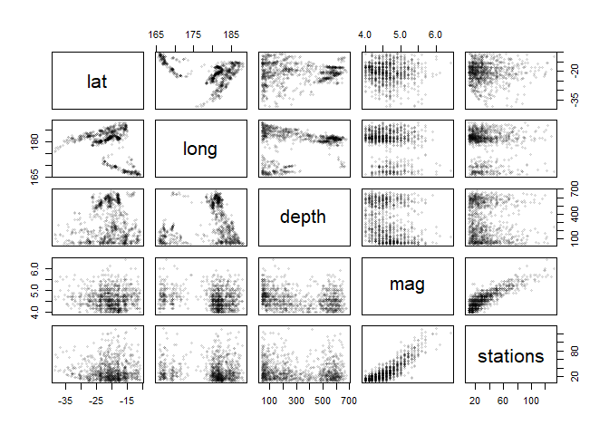

### 3.3.2 Entender las variables

> Latitud (lat)

La variable Latitud o **lat**, es el valor numérico de la Latitud geográfica del evento.

> Longitud (long)

La variable Longitud o **long** es el valor numérico de la Longitud geográfica del evento.

> Profundidad (depth)

La variable Profundidad o **depth** es el valor numérico de la profundidad en kilómetros.

> Magnitud (mag)

La variable Magnitud o **mag** es el valor numérico de la magnitud en la escala de Richter.

> Estaciones (stations)

La variable Estaciones o **stations** es el valor numérico de la cantidad de estaciones que informan.

## 3.4 Gráficos

### 3.4.1 Gráfico por faces

En este gráfico de facetas observamos por grupos la profundidad de los terremotos por su magnitud y su ubicación.

[figure not shown]

[figure not shown]

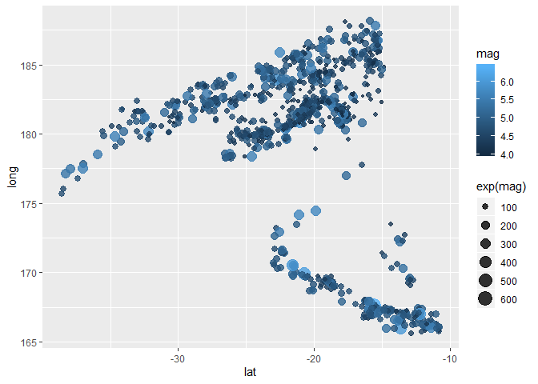

### 3.4.2 Gráfico Dinámico con Shiny

[output not shown]

Shiny applications not supported in static R Markdown documents